# Agreement-effects analysis

Matt Jaquiery (matt.jaquiery@psy.ox.ac.uk)

Here we run code which simulates agents who exhange advice with one another and update their weightings of one another based on the agreement of their initial decisions and advice.

## Model structure

Agents ($^a$) make categorical decisions about a continuous variable in the world which changes at each time point($_t$) ($x_t \sim \mathcal{N}(\mu=0, \theta^=1)$). This intial estimate ($i_t^a$) is the result of combining the true value ($x_t$) with the agent’s bias ($b_t^a$), and adding noise based on the agent’s sensitivity ($s^a$):

$$i_t^a = (x_t + b_t^a) s_t^a$$
where $s_t^a \sim \mathcal{N}(\mu=0, \theta^=s^a)$.

Agents then get the opportunity to make a final decision ($f_t^a$) by considering the initial estimate of another (randomly chosen) agent ($^z$) as their advice. This advice is weighted by the level of trust agent $^a$ has in agent $^z$ ($\omega_t^{a,z}$) at that moment:

$$f_t^a = (1 - \omega_t^{a,z}) i_t^a + \omega_t^{a,z} i_t^z$$

After making the final decision, the agent can then update their trust in the their advisor. The size of this update is governed by the learning rate ($\lambda$), and can either be based purely on agreement:

$$\omega_{t+1}^{a,z} = \begin{cases}
\omega_t^{a,z} + \lambda & \text{sign}(i_t^a) = \text{sign}(i_t^z) \\
\omega_t^{a,z} - \lambda & \text{sign}(i_t^a) \neq \text{sign}(i_t^z)
\end{cases}$$

or weighted by confidence:

$$\omega_{t+1}^{a,z} = \begin{cases}
\omega_t^{a,z} + \lambda |i_t^a| & \text{sign}(i_t^a) = \text{sign}(i_t^z) \\
\omega_t^{a,z} - \lambda |i_t^a| & \text{sign}(i_t^a) \neq \text{sign}(i_t^z)
\end{cases}$$

## Example

To make a simple example where we can see the structure of the network and how it evolves, we’ll use normal distributions for bias and sensitivity, and initialise bias around +/- 1 (values are expressed in standard deviations of the distribution underlying the true value).

```r
# hide the library loading details
suppressWarnings(suppressPackageStartupMessages(source('agreement-effects.R')))
suppressWarnings(suppressPackageStartupMessages(library(broom)))

theme_set(theme_light() + theme(
  legend.position = 'top',
  panel.grid.minor = element_blank(),
  panel.grid.major.x = element_blank()
))

set.seed(20191127)          # Use the same seed each time so simulations are comparable

model <- runSimulation(
  n = list(p = 10, d = 200),
  conf = T,
  biasMean = 1,
  biasSD = 1,
  sensitivitySD = 1,
  learningRate = .1
)
```

### Evolution of Weight

The first thing to look at is the network graph for the agents. This graph rapidly becomes uninformative as the number of agents rises, but for a few agents it helps show the model structure. Agents are coloured and arranged according to their bias, with deeper colours indicating stronger biases and different colours indicating different directions of bias. Heavier lines between agents indicate greater weight of advice flowing from the source to the destination.

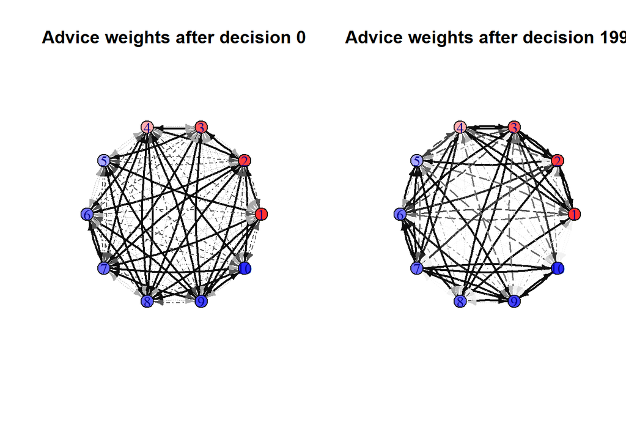

```r
networkGraph(model)
```

we should see that the network starts off with a random pattern of connections. These connections then become much stronger between agents who share biases compared to between agents who do not share biases. By and large, the two connections between any two agents should be fairly similar in weight to one another.

### Effects of Bias Similarity on Weight

We expect agents to increase their trust in other agents roughly in proportion to the extent to which they share a bias with those agents. We can thus take the correlation between the extent to which two agents share bias and the weight they assign one another as a measure of how pronounced the effect of bias is on trust.

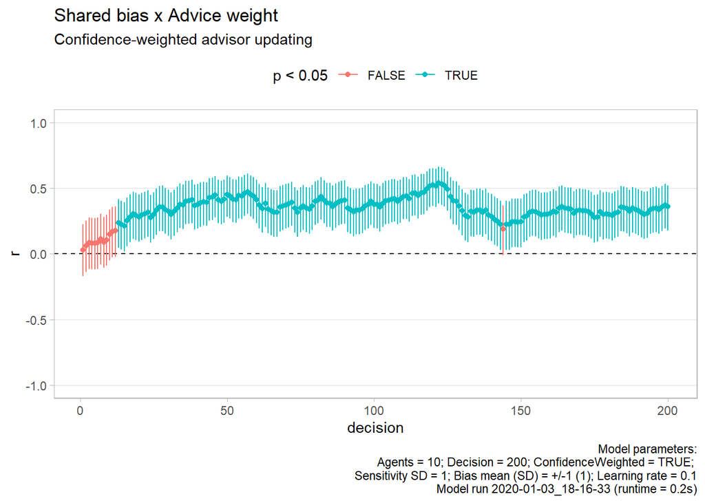

```r
biasGraph(model)
```

This graph shows Pearson’s $r$ statistic for the correlation between shared bias and advice weight at each decision. The error bars show 95% confidence intervals, and whether these include 0 is indicated by the colour.

### Effects of Sensitivity on Weight

We also expect sensitivity to affect the trust agents have in one another. This is the normative engine the shared bias corrupts: generally two independent agents with a better-than-chance ability to identify correct answers will converge on the correct answer more frequently than they converge on the incorrect one, so updating trust where they agree is sensible. This is complicated by the directionality of a tie: it is not obvious whether only indegree (weights others place on an agent) should increase as that agent’s sensitivity increases, or whether outdegree (weight an agent places on others) decreases through a similar mechanism (the more accurate I am, the less I should move my estimate based on a random other person’s assessment).

These models, however, only care about agreement/confidence; they do not know the actual answer and never update in response to feedback.

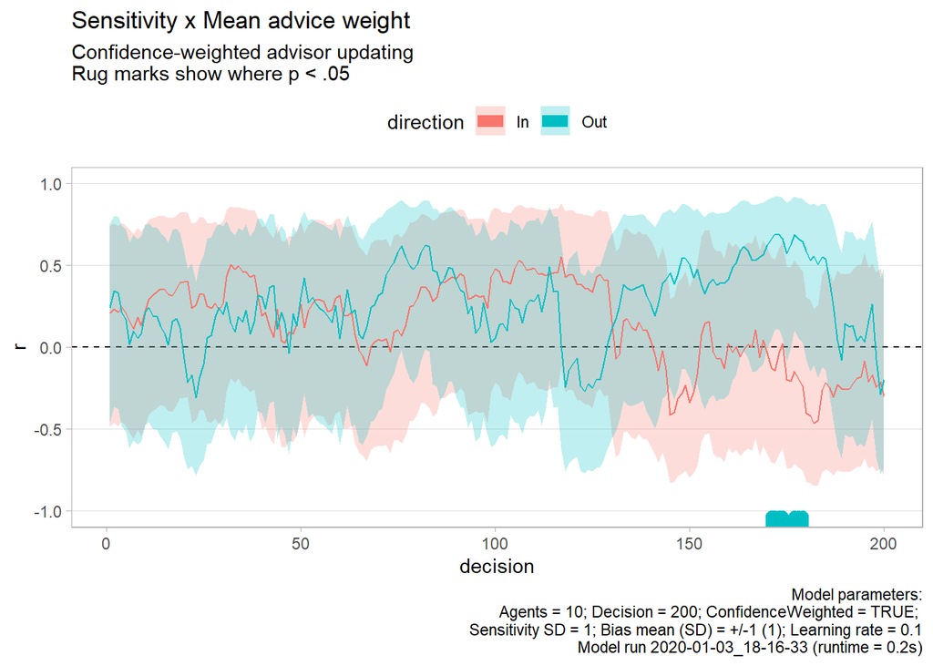

```r
sensitivityGraph(model)
```

This graph shows Pearson’s $r$ for the correlation between an agent’s sensitivity and the mean weight of their incoming and outgoing ties at each decision time. Where the 95% confidence limits (shaded areas) do not touch 0 there are rugmarks at the top or bottom. In this particular graph the correlations are essentially noise: the effect of bias is substantially stronger and renders the effect of sensitivity irrelevant.

## Unbiased agents

Agents without biases probably benefit from upweighting those who agree, depending on the base probability of the agent being correct. In this environment, agents have different sensitivities, and this determines how good they are at being able to identify the correct answer.

### Using confidence

We first explore this allowing agents to update their trust based on their own confidence in their initial answers.

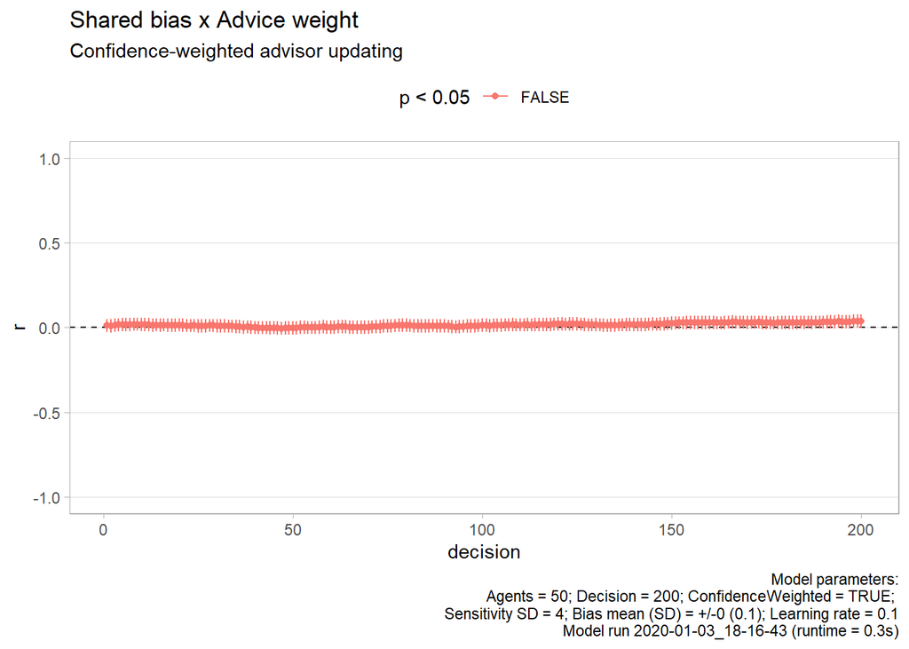

```r
set.seed(20191127)

model <- runSimulation(
  n = list(p = 50, d = 200),
  conf = T,
  biasMean = 0,
  biasSD = .1,
  sensitivitySD = 4,
  learningRate = .1
  )

biasGraph(model)
```

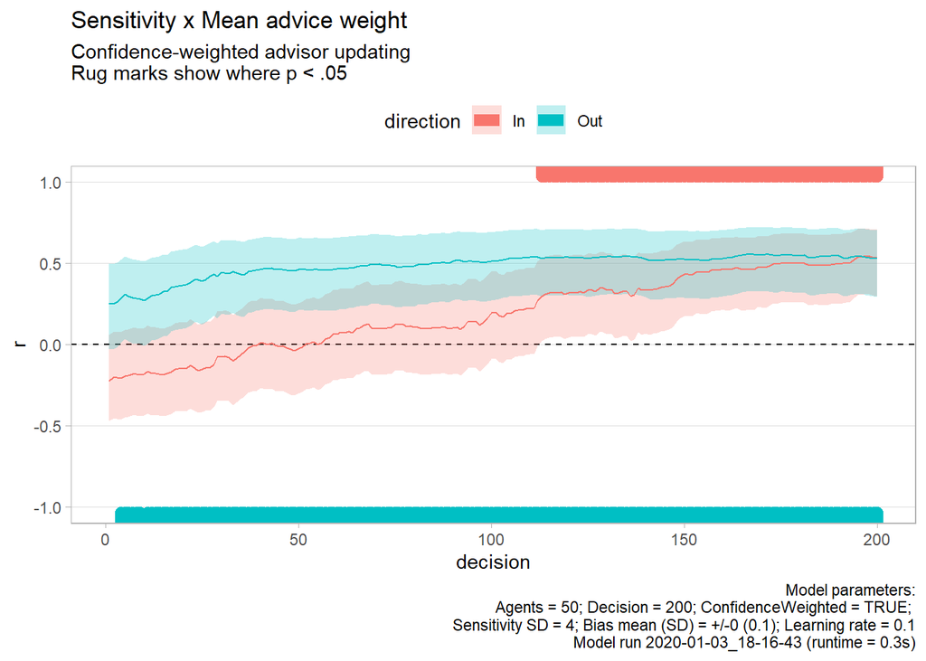

```r
sensitivityGraph(model)
```

### Using agreement only

We can run the same simulation but disable the metacognitive component, so that agents now increase or decrease their trust in others ony on the basis of agreement, rather than on the basis of agreement weighted by their own intial confidence.

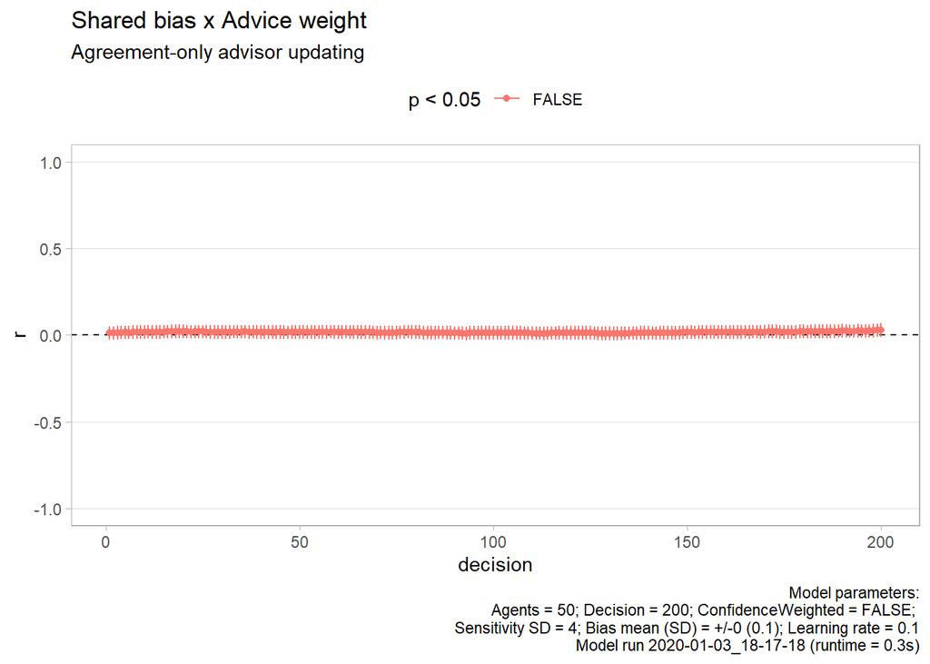

```r
set.seed(20191127)

model <- runSimulation(
  n = list(p = 50, d = 200),
  conf = F,
  biasMean = 0,
  biasSD = .1,
  sensitivitySD = 4,
  learningRate = .1
  )

biasGraph(model)
```

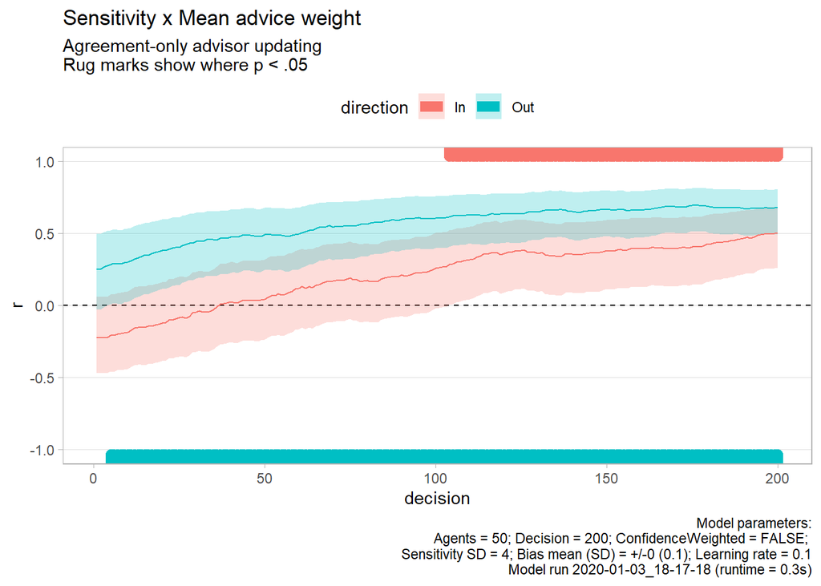

```r
sensitivityGraph(model)
```

The results of the simulation using agreement only are qualitatively identical to the confidence-weighted ones. Later we can dig into the temporal dynamics, but the effects produced are the same.

## Biased agents

To explore the dominant effects of biases, we can limit the sensitivity variation dramatically, and slightly increase the strength of the mean bias.

### Using confidence

Again, we can look at the results when agents use their confidence in their initial decisions to weight trust updates (in a direction determined by agreement).

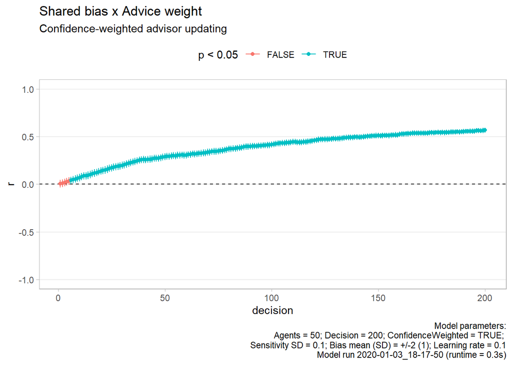

```r
set.seed(20191127)

model <- runSimulation(
  n = list(p = 50, d = 200),
  conf = T,
  biasMean = 2,
  biasSD = 1,
  sensitivitySD = .1,
  learningRate = .1
  )

biasGraph(model)
```

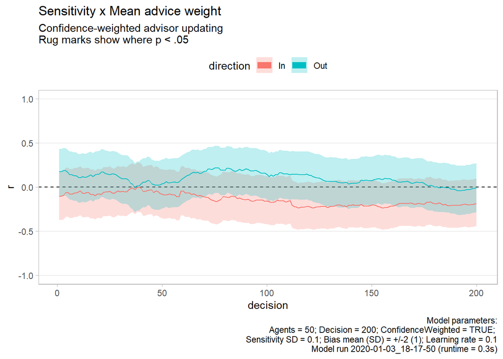

```r
sensitivityGraph(model)
```

The effect of shared bias in the model is almost immediate, pronouced, and increases steadily over the duration of the simulation. As time goes on, agents who share a bias become increasingly influence by one another. Note that in these simulations an agent’s bias is fixed.

As we may expect with so little variation allowed around sensitivity, there is no meaningful correlation between an agent’s sensitivity and the extent to which it trusts or is trusted by others.

### Using agreement only

We can also explore this using the non-weighted, agreement-only construction.

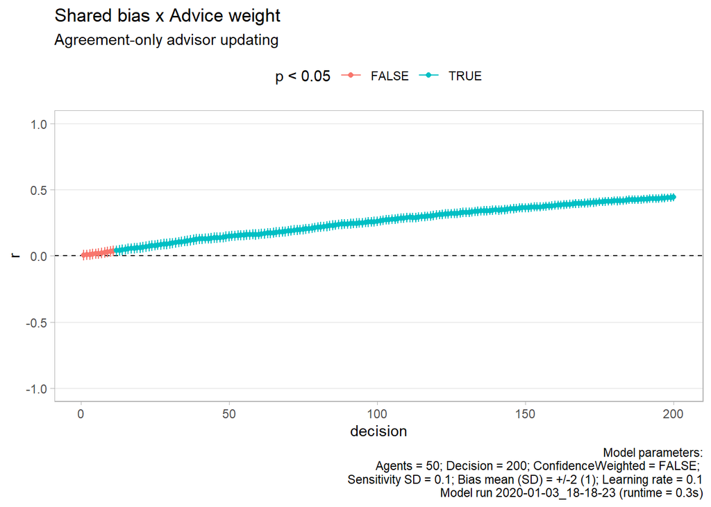

```r
set.seed(20191127)

model <- runSimulation(
  n = list(p = 50, d = 200),
  conf = F,
  biasMean = 2,
  biasSD = 1,
  sensitivitySD = .1,
  learningRate = .1
  )

biasGraph(model)
```

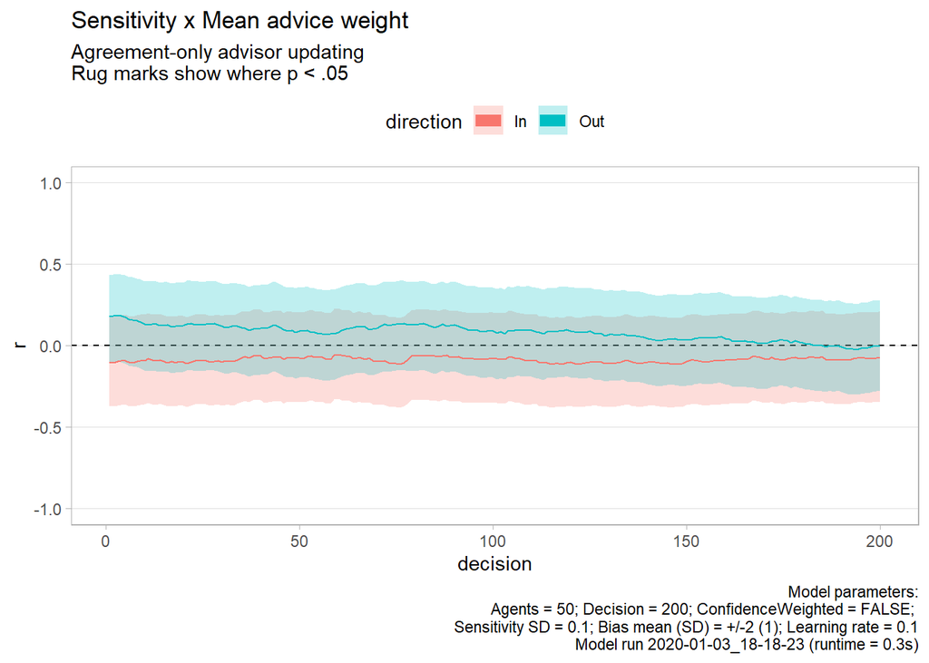

```r
sensitivityGraph(model)
```

Qualitatively identical results are obtained without using confidence weighting.

## Comparison of non/metacognitive models

### Temporal evolution of bias correlation

The above results have the same pattern whether or not the models use metacognitive weighting. It is possible that metacognition alters the timeline, speeding up or slowing down the rate at which the positive feedback processes function to produce strong associations between sensitivity or bias similarity and advice weight. A first step for investigating this is to chart the evolution of the correlation coefficient until it peaks and measure the time taken to reach that peak.

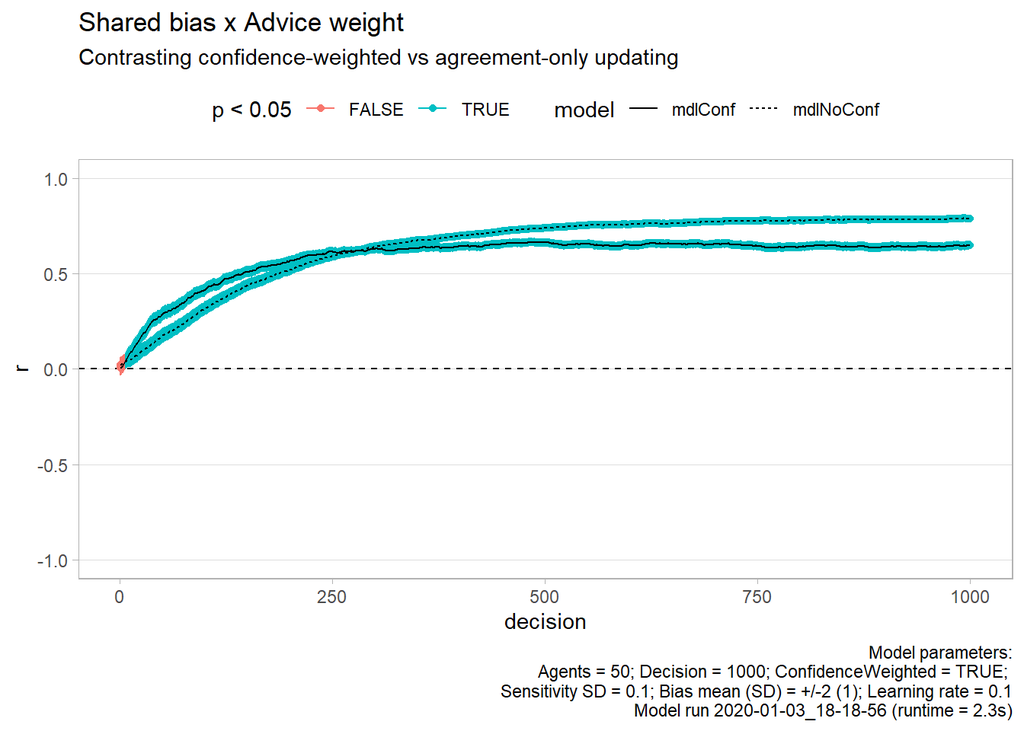

```r
set.seed(20191127)

mdlConf <- runSimulation(
  n = list(p = 50, d = 1000),
  conf = T,
  biasMean = 2,
  biasSD = 1,
  sensitivitySD = .1,
  learningRate = .1
  )

mdlNoConf <- runSimulation(
  n = list(p = 50, d = 1000),
  conf = F,
  biasMean = 2,
  biasSD = 1,
  sensitivitySD = .1,
  learningRate = .1
)

gC <- biasGraph(mdlConf)

# duplicate bias calculation for mdlNoConf
cors <- .biasCorrelation(mdlNoConf)

gC +
  geom_point(data = cors) +
  geom_errorbar(data = cors, width = 0) +
  geom_line(data = rbind(cors %>% mutate(model = "mdlNoConf"),
                         .biasCorrelation(mdlConf) %>% mutate(model = "mdlConf")),
            aes(linetype = model), colour = "black") +
  labs(subtitle = "Contrasting confidence-weighted vs agreement-only updating")
```

The two models have different trajectories for the evolution of the bias-weight correlations: the weighted model has an initially steeper incline, but the unweighted model eventually reaches a higher level.

### Effect of bias strength

We should explore whether the derivatives, as well as the asymptotes, are functions of the bias strength, and especially whether the relationship between them changes as so. For these investigations we run the models several times because the outputs can vary and we want to be able to draw conclusions (even approximate ones!) about the patterns.

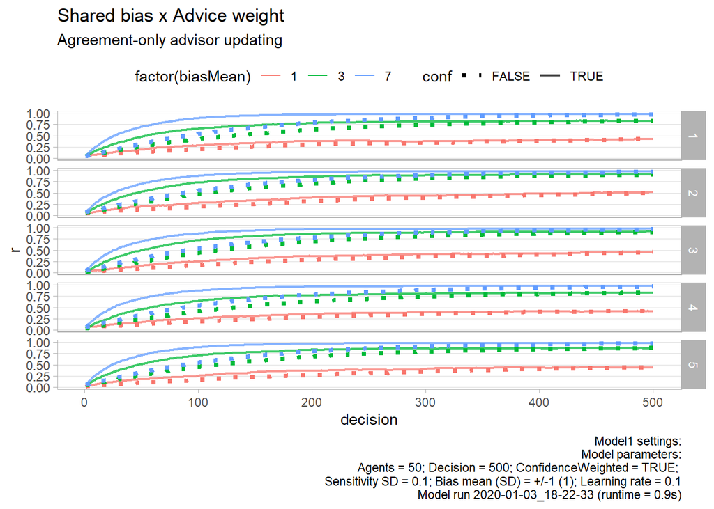

```r
params <- tibble(
  biasMean = c(1, 3, 7),
  p = 50,
  d = 500
) %>%
  nest(-biasMean) %>%
  rename(n = data) %>%
  mutate(
    biasSD = 1,
    sensitivitySD = .1,
    learningRate = .1
  )

coefs <- NULL
runs <- 5
set.seed(20191127)
seeds <- sample(1:2^15, runs)

for (run in 1:runs) {
  set.seed(seeds[run])
  mdlsConf <- runSimulations(params)
  set.seed(seeds[run])
  mdlsNoConf <- runSimulations(params %>% mutate(conf = F))

  for (m in c(mdlsConf, mdlsNoConf)) {
    tmp <- .biasCorrelation(m)
    coefs <- rbind(coefs,
                   tmp %>% mutate(run = run,
                                  conf = m$parameters$conf,
                                  biasMean = m$parameters$biasMean,
                                  seed = sum(m$random$seed)))
  }
}

coefs %>% ggplot(aes(x = decision,
                     y = r, ymin = ciL, ymax = ciH,
                     colour = factor(biasMean),
                     linetype = conf,
                     size = conf,
                     alpha = conf)) +
  geom_line() +
  scale_y_continuous(limits = c(0, 1)) +
  scale_size_manual(values = c(1.5, .75)) +
  scale_linetype_manual(values = c("dotted", "solid")) +
  scale_alpha_manual(values = c(1, .75)) +
  labs(title = 'Shared bias x Advice weight',
       subtitle = ifelse(model$parameters$conf,
                         'Confidence-weighted advisor updating',
                         'Agreement-only advisor updating'),
       caption = paste0(
         "Model1 settings:\n",
         settingsStr(mdlsConf[[1]])
         )) +
  facet_grid(run~.)
```

Increased mean bias increases the level of the correlation at which the plateau occurs. Increased mean bias also increases the speed with which the correlation reaches its plateau. Both these effects occur with and without confidence weighting. Including confidence weighting dramatically accellerates the speed of plateauing, and this increase is itself probably increased in magnitude by the stength of the baises. The effects are fairly stable across runs, although the exact trajectory is a product of the specific biases generated, which results in variation in final correlation point and time taken to reach it.

#### Comparing the quadratic model coefficients

The above models’ data can be approximated with quadratic models using first and second order polynomials of $decision$ to predict $correlation coefficient$. The models for the above graph look similar to the above graph, as we expect:

```r
# Fit parameters for quadratic function
fits <- coefs %>%
  group_by(run, biasMean, conf) %>%
  do(lmQ = lm(r ~ poly(decision, 2, raw = T), data = .)) %>%
  tidy(lmQ) %>%
  select(run:estimate) %>%
  spread(term, estimate) %>%
  rename(i = `(Intercept)`,
         d = `poly(decision, 2, raw = T)1`,
         dSq = `poly(decision, 2, raw = T)2`) %>%
  full_join(coefs) %>%
  mutate(r_hat = i + d * decision + dSq * (decision ^ 2),
         u = paste0(conf, biasMean, sep = ":"))
```

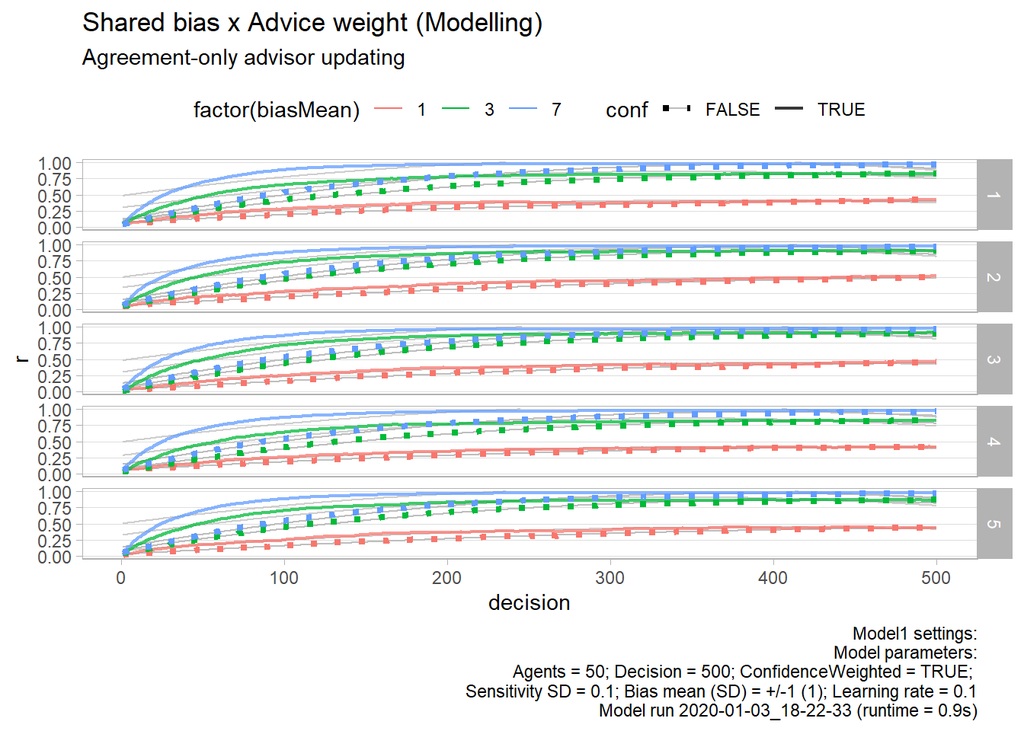

```r
fits %>% ggplot(aes(x = decision,
                    y = r,
                    colour = factor(biasMean),
                    linetype = conf,
                    size = conf,
                    alpha = conf)) +
  geom_line(aes(y = r_hat, group = u),
            colour = "grey", size = .5, linetype = "solid") +
  geom_line() +
  scale_y_continuous(limits = c(0, 1)) +
  scale_size_manual(values = c(1.5, .75)) +
  scale_linetype_manual(values = c("dotted", "solid")) +
  scale_alpha_manual(values = c(1, .75)) +
  labs(title = 'Shared bias x Advice weight (Modelling)',
       subtitle = ifelse(model$parameters$conf,
                         'Confidence-weighted advisor updating',
                         'Agreement-only advisor updating'),
       caption = paste0(
         "Model1 settings:\n",
         settingsStr(mdlsConf[[1]])
         )) +
  facet_grid(run~.)
```

These fitted functions seem to be far better fitted for the non-confidence models. We can explore and compare the parameters for these models.

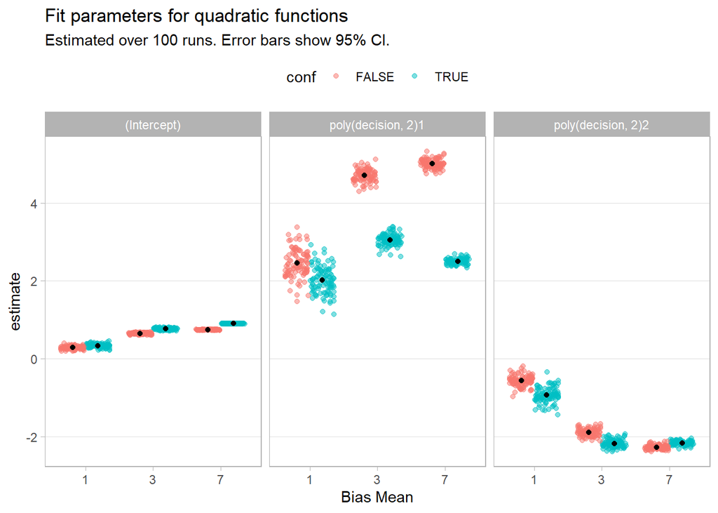

```r
# May be worth paralellizing this

params <- tibble(
  biasMean = c(1, 3, 7),
  p = 50,
  d = 500
) %>%
  nest(-biasMean) %>%
  rename(n = data) %>%
  mutate(
    biasSD = 1,
    sensitivitySD = .1,
    learningRate = .1
  )

coefs <- NULL
runs <- 100
set.seed(20191127)
seeds <- sample(1:2^15, runs)

for (run in 1:runs) {
  set.seed(seeds[run])
  mdlsConf <- runSimulations(params)
  set.seed(seeds[run])
  mdlsNoConf <- runSimulations(params %>% mutate(conf = F))

  for (m in c(mdlsConf, mdlsNoConf)) {
    tmp <- .biasCorrelation(m)
    coefs <- rbind(coefs,
                   tmp %>% mutate(run = run,
                                  conf = m$parameters$conf,
                                  biasMean = m$parameters$biasMean,
                                  seed = sum(m$random$seed)))
  }
}

# Fit parameters for quadratic function
fits <- coefs %>%
  group_by(run, biasMean, conf) %>%
  do(lmQ = lm(r ~ poly(decision, 2), data = .)) %>%
  tidy(lmQ)

dw <- .75

ggplot(fits, aes(x = factor(biasMean), y = estimate, colour = conf)) +
  geom_point(position = position_jitterdodge(jitter.width = .35,
                                             dodge.width = dw),
             alpha = .5) +
  stat_summary(geom = "point", fun.y = mean, position = position_dodge(dw),
               colour = "black", aes(group = conf)) +
  stat_summary(geom = "errorbar", fun.data = mean_cl_normal, width = 0,
               position = position_dodge(dw), colour = "black",
               aes(group = conf)) +
  facet_grid(~term) +
  labs(x = "Bias Mean",
       title = "Fit parameters for quadratic functions",
       subtitle = "Estimated over 100 runs. Error bars show 95% CI.")
```

It seems that only the first order polynomial differs between the confidence and no-confidence cases, and only when the bias mean is reasonably high. There are only slight differences for intercepts and second-order polynomial terms.

### Effect of learning rate

Likewise, the learning rate may affect these conclusions.

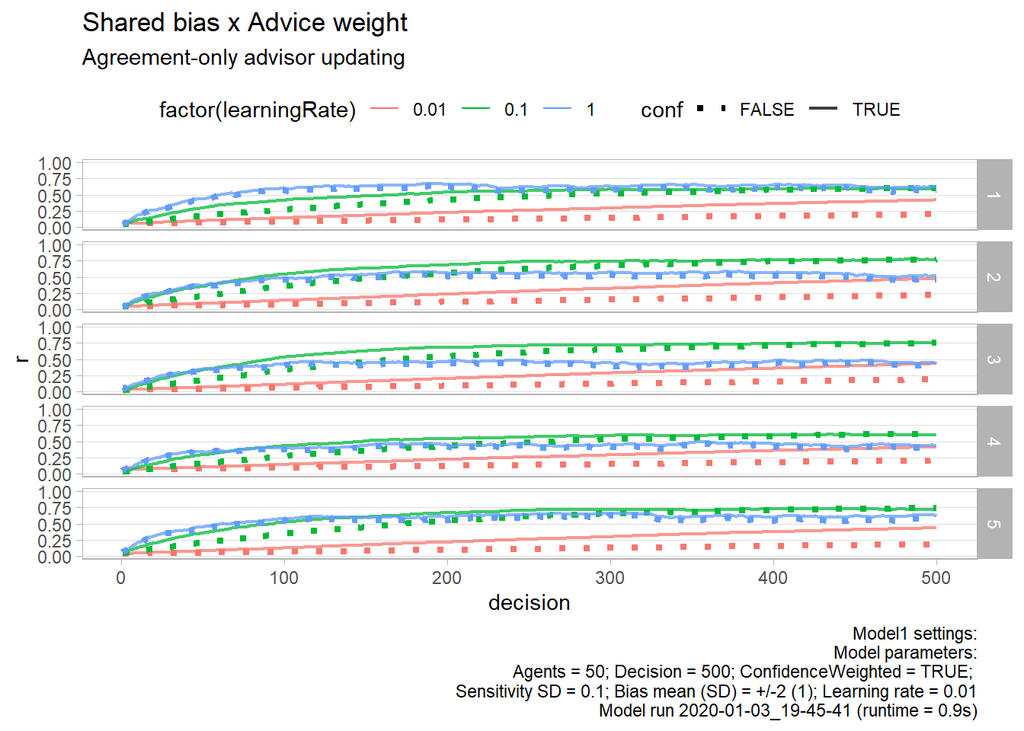

```r
params <- tibble(
  learningRate = c(.01, .1, 1),
  p = 50,
  d = 500
) %>%
  nest(-learningRate) %>%
  rename(n = data) %>%
  mutate(
    biasMean = 2,
    biasSD = 1,
    sensitivitySD = .1
  )

coefs <- NULL
runs <- 5
set.seed(20191127)
seeds <- sample(1:2^15, runs)

for (run in 1:5) {
  set.seed(seeds[run])
  mdlsConf <- runSimulations(params)
  set.seed(seeds[run])
  mdlsNoConf <- runSimulations(params %>% mutate(conf = F))

  for (m in c(mdlsConf, mdlsNoConf)) {
    tmp <- .biasCorrelation(m)
    coefs <- rbind(coefs,
                   tmp %>% mutate(run = run,
                                  conf = m$parameters$conf,
                                  learningRate = m$parameters$learningRate))
  }
}

coefs %>% ggplot(aes(x = decision,
                     y = r, ymin = ciL, ymax = ciH,
                     colour = factor(learningRate),
                     linetype = conf,
                     size = conf,
                     alpha = conf)) +
  geom_line() +
  scale_y_continuous(limits = c(0, 1)) +
  scale_size_manual(values = c(1.5, .75)) +
  scale_linetype_manual(values = c("dotted", "solid")) +
  scale_alpha_manual(values = c(1, .75)) +
  labs(title = 'Shared bias x Advice weight',
       subtitle = ifelse(model$parameters$conf,
                         'Confidence-weighted advisor updating',
                         'Agreement-only advisor updating'),
       caption = paste0(
         "Model1 settings:\n",
         settingsStr(mdlsConf[[1]])
         )) +
  facet_grid(run~.)
```

Learning rate affects the speed with which plateauing is achieved, as well as the smoothness of the trajectory. In several runs, a high learning rate limits the level of correlation which can be achieved between shared bias and advice weight, although it doesn’t appear to matter whether or not confidence is allowed to weight the updating.

### Temporal evolution of sensitivity correlation

The patterns we see for the differential temporal evolution of the shared bias x advice weight correlation depending upon the presence of metacognitive weighting may also be evident for the relationship between sensitivity and advice weight. We explore that possibility here.

Note: the confidence intervals in the sensitivity x advice weight correlations are quite wide. See the graphs in the earlier sections to get a sense of this.

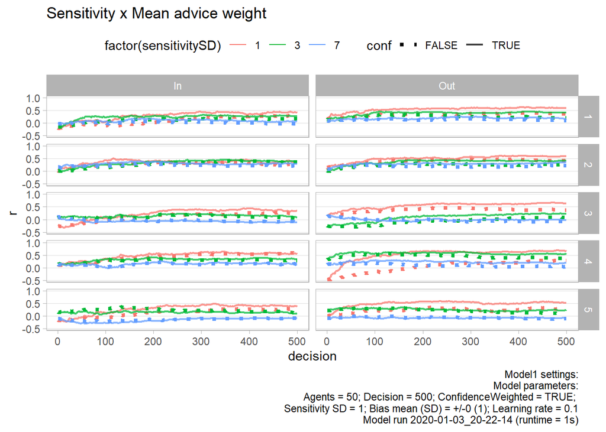

```r
params <- tibble(
  sensitivitySD = c(1, 3, 7),
  p = 50,
  d = 500
) %>%
  nest(-sensitivitySD) %>%
  rename(n = data) %>%
  mutate(
    biasMean = 0,
    biasSD = 1,
    learningRate = .1
  )

sens <- NULL
runs <- 5
set.seed(20191127)
seeds <- sample(1:2^15, runs)

for (run in 1:5) {
  set.seed(seeds[run])
  mdlsConf <- runSimulations(params)
  set.seed(seeds[run])
  mdlsNoConf <- runSimulations(params %>% mutate(conf = F))

  for (m in c(mdlsConf, mdlsNoConf)) {
    tmp <- .sensitivityCorrelation(m)
    sens <- rbind(sens,
                   tmp %>% mutate(run = run,
                                  conf = m$parameters$conf,
                                  sensitivitySD = m$parameters$sensitivitySD))
  }
}

sens %>% ggplot(aes(x = decision,
                    y = r, ymin = ciL, ymax = ciH,
                    colour = factor(sensitivitySD),
                    linetype = conf,
                    size = conf,
                    alpha = conf)) +
  geom_line() +
  scale_y_continuous(limits = c(-.5, 1)) +
  scale_size_manual(values = c(1.5, .75)) +
  scale_linetype_manual(values = c("dotted", "solid")) +
  scale_alpha_manual(values = c(1, .75)) +
  labs(title = 'Sensitivity x Mean advice weight',
       caption = paste0(
         "Model1 settings:\n",
         settingsStr(mdlsConf[[1]])
         ))  +
  facet_grid(run ~ direction)
```

Where the sensitivities of the agents are likely to be similar (low sensitivity SD), a positive correlation tends to emerge between an agent’s sensitivity and the weights of both their incoming and outgoing connections. This means that sensitive agents are likely to be more influential (as expected), and also more readily influenced (presumably because they have higher agreement rates due to their own accuracy).

As the variation in sensitivities increases, the expected correlation between the agents’ sensitivities and the weights of their incoming and outgoing connections unravel. This may be because most agents are so poor at the task as to be essentially answering at random, dissolving the expected bias in favour of agreement between accurate agents which powers the increases in tie strength as a function of sensitivity.

It appears as though the confidence-weighted correlation plateau point acts as a limit for the non-confidence version at all levels of sensitivity variation.

# Credits

## Acknowledgements

Thanks as always to Nick Yeung and the other folks at the [ACC Lab](https://www.psy.ox.ac.uk/research/attention-cognitive-control-lab).

## R Packages

```r
suppressPackageStartupMessages(library(knitr))
# list packages
packageNames <- (.packages())
# don't include very core package
packageNames <- packageNames[!(packageNames %in%
                                 rownames(installed.packages(
                                   priority = "base")))]
# but do include the base package
packageNames <- c("base", packageNames)
out <- NULL
for (p in packageNames) {
  out <- rbind(out, data.frame('Package' = p,
                               'Citations' = paste(format(citation(p),
                                                          style = 'textVersion'),
                                                   collapse = '<br/><br/>')))
}

kable(out)
```

| Package | Citations |
| --- | --- |
| base | R Core Team (2018). R: A language and environment for statistical computing. R Foundation for Statistical Computing, Vienna, Austria. URL https://www.R-project.org/. |
| knitr | Yihui Xie (2019). knitr: A General-Purpose Package for Dynamic Report Generation in R. R package version 1.24. Yihui Xie (2015) Dynamic Documents with R and knitr. 2nd edition. Chapman and Hall/CRC. I… |
| broom | David Robinson and Alex Hayes (2019). broom: Convert Statistical Analysis Objects into Tidy Tibbles. R package version 0.5.2. https://CRAN.R-project.org/package=broom |
| igraph | Csardi G, Nepusz T: The igraph software package for complex network research, InterJournal, Complex Systems 1695. 2006. http://igraph.org |
| forcats | Hadley Wickham (2019). forcats: Tools for Working with Categorical Variables (Factors). R package version 0.4.0. https://CRAN.R-project.org/package=forcats |
| stringr | Hadley Wickham (2019). stringr: Simple, Consistent Wrappers for Common String Operations. R package version 1.4.0. https://CRAN.R-project.org/package=stringr |
| dplyr | Hadley Wickham, Romain François, Lionel Henry and Kirill Müller (2019). dplyr: A Grammar of Data Manipulation. R package version 0.8.3. https://CRAN.R-project.org/package=dplyr |
| purrr | Lionel Henry and Hadley Wickham (2019). purrr: Functional Programming Tools. R package version 0.3.3. https://CRAN.R-project.org/package=purrr |
| readr | Hadley Wickham, Jim Hester and Romain Francois (2018). readr: Read Rectangular Text Data. R package version 1.3.1. https://CRAN.R-project.org/package=readr |
| tidyr | Hadley Wickham and Lionel Henry (2019). tidyr: Easily Tidy Data with ‘spread()’ and ‘gather()’ Functions. R package version 0.8.3. https://CRAN.R-project.org/package=tidyr |
| tibble | Kirill Müller and Hadley Wickham (2019). tibble: Simple Data Frames. R package version 2.1.3. https://CRAN.R-project.org/package=tibble |
| ggplot2 | H. Wickham. ggplot2: Elegant Graphics for Data Analysis. Springer-Verlag New York, 2016. |
| tidyverse | Hadley Wickham (2017). tidyverse: Easily Install and Load the ‘Tidyverse’. R package version 1.2.1. https://CRAN.R-project.org/package=tidyverse |

## Funding

Matt Jaquiery is funded by a studentship from the [Medical Research Council](https://mrc.ukri.org/) (reference 1943590) and the University of Oxford [Department of Experimental Psychology](https://www.psy.ox.ac.uk/) (reference 17/18_MSD_661552).

## Technical details

```r
cat(paste('Time stamp:', Sys.time(), '\n\n'))
cat('Runtime \n')
proc.time()
cat('\n')
```